# Capítulo 7: Análisis exploratorio de datos de microbiomas

Andrés Arredondo (email_1@gmail.com)

Adriana Haydé Contreras Peruyero (haydeeperuyero@gmail.com)

David Alberto García Estrada (@gmail.com)

2022-09-03

# Datos de Ratones y Humanos

# Análisis exploratorio con resumen gráfico

## Gráficos de riqueza

En el capítulo anterior se exploró la diversidad alfa, en este capítulo vamos a explorar un gráfico relacionado a esto. Para esto, se usa la función `plot_richness()` del paquete `phyloseq`. Generalmente, la riqueza se refiere a un gráfico del número toal de especies, taxones u OTUs en un ambiente, pero está función también nos da otras figuras relacionadas a otras diversidades.

Lo primero que debemos hacer es instalar el paquete y leer los datos.

```r
#Para instalar el paquete, usamos Bioconductor

#if (!require("BiocManager", quietly = TRUE))
 # install.packages("BiocManager")

#BiocManager::install("phyloseq")
```

En la carpeta `data` se encuentra la base de datos a usar `VdrFecalGenusCounts.csv`.

```r
setwd("D:/Users/hayde/Documents/R_sites/Equipo4")
```

```r
library(phyloseq)
library(ggplot2)
abund_table=read.csv("./data/VdrFecalGenusCounts.csv",row.names=1,check.names=FALSE)
abund_table<-t(abund_table)
```

Lo primero que se debe de hacer es contruir nuestro objeto `phyloseq`. Este objeto se contruye tomando en cuenta los siguientes componentes: - Tabla OTU. - Datos muestra. - Tabla de taxonomía. - Árbol filogenético.

Se deben de proporcionar dos objetos de datos pero el orden en que se proporcionan no es importante. Construimos primero nuestra tabla de metadatos con los siguientes comandos.

```r
meta_table <- data.frame(row.names=rownames(abund_table),t(as.data.frame(strsplit(rownames(abund_table),"_"))))
meta_table$Group <- with(meta_table,ifelse(as.factor(X2)%in% c(11,12,13,14,15),c("Vdr-/-"), c("WT")))
```

Convertimos los datos al formato `phyloseq`.

```r
OTU = otu_table(as.matrix(abund_table), taxa_are_rows = FALSE)
SAM = sample_data(meta_table)
physeq <- merge_phyloseq(phyloseq(OTU),SAM)
physeq
```

```
## phyloseq-class experiment-level object
## otu_table()   OTU Table:         [ 248 taxa and 8 samples ]
## sample_data() Sample Data:       [ 8 samples by 4 sample variables ]
```

Una vez que tenemos nuestro objeto `phyloseq`, podemos usar la función `plot_richness()` para contruir graficar las diversidades alpha observadas y estimadas.

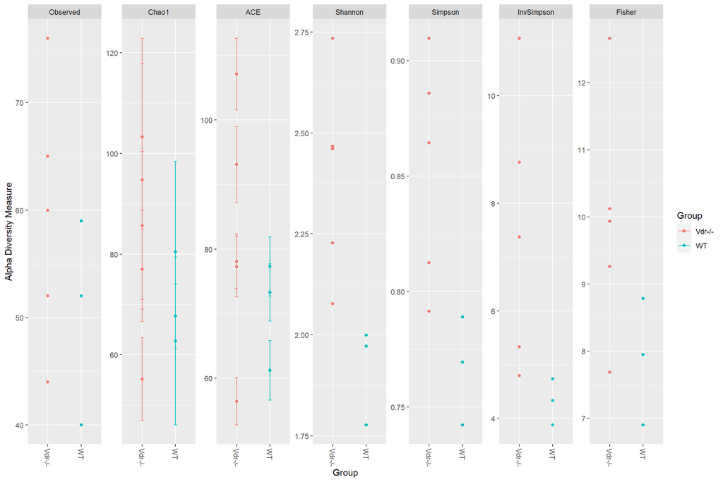

Gráficos de diversidad alpha con Vdr y grupos WT en muestras de heces.

Esta función también nos permite seleccionar solo algunas diversidades. El siguiente es un ejemplo usando solo dos diversidades, la de Chao1 y Shannon.

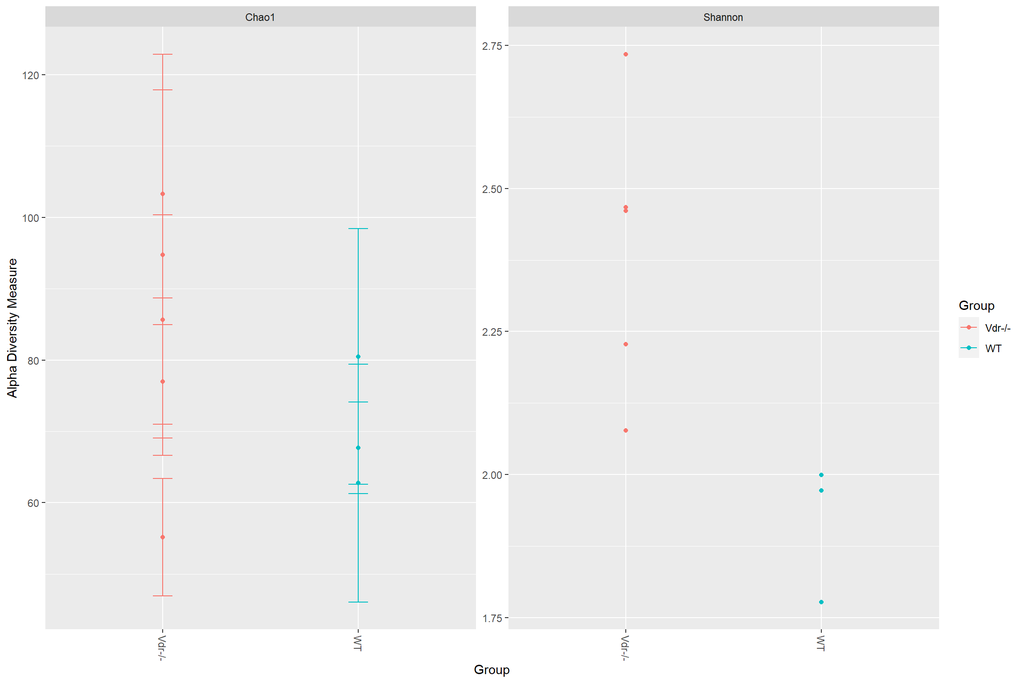

Gráficos de diversidad alpha seleccionando las diversidades de Chao y Shannon.

## Barras de abundancia

La herramienta de `phyloseq` que nos permite graficar las barras de abundancia es `plot_bar()`.

## Mapas de calor

## Redes

## Árbol filogenético

# Clusters

## Distancias

## Diferentes tipos de clústers

### Single

### Complete

### Average

### Ward

# Ordination

## PCA

## PCoA

## NMDS

## CA

## RDA

## CCA

## CAP

# Conlusiones